# introduction about the data:

the data is about Airbag and other influences on car accident fatalities and injuries like weather the impact was frontal or not the seatbelt was belted or not and the speed of the impact among others

# operations performed on the data

- creating a dummy variable for death making it easy to get rate of death
- adding factor variable for direction of impact easier to deal with than frontal int variable in the data
- adding factor variable for injury degree easier to deal with than injseverity int variable in the data
- adding a dummy variable for seatbelt

# Univariate Plots Section

## estimated impact speeds distribution

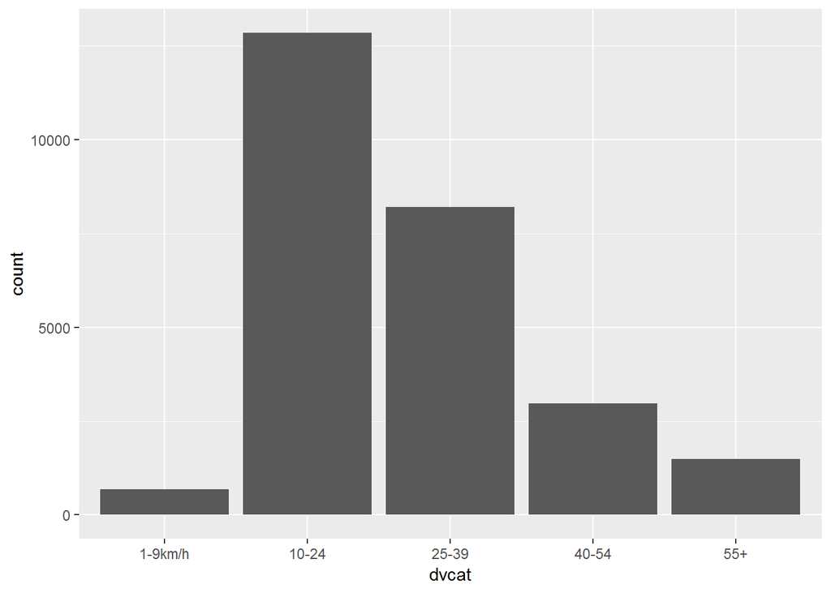

```
## 1-9km/h   10-24   25-39   40-54     55+
##     686   12848    8214    2977    1492
```

sound strange the most accidents occurred in the range 10-24 and the faster above it the less accidents

## gender count

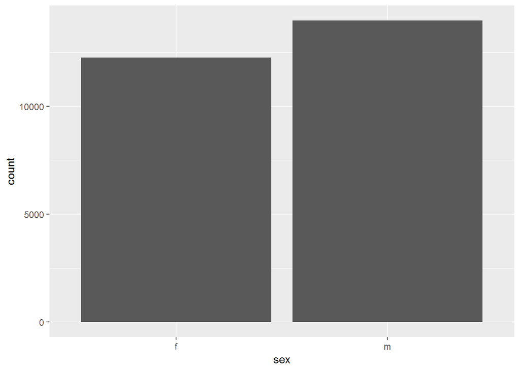

```
##     f     m
## 12248 13969
```

sound that males have more accidents than females

## age distribution

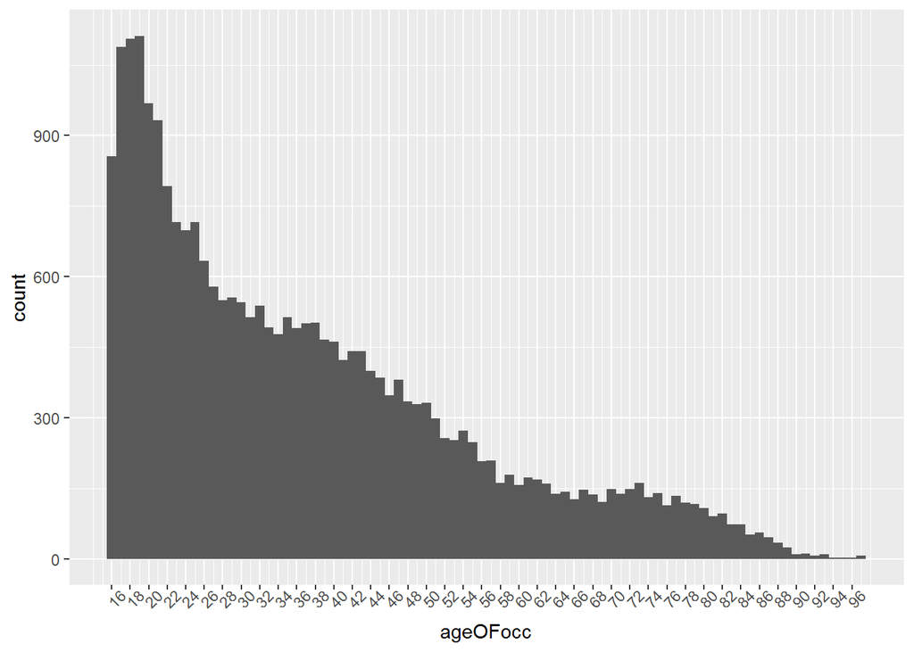

sound that the older the less accidents with the peak between 16 and 24

## year of car model

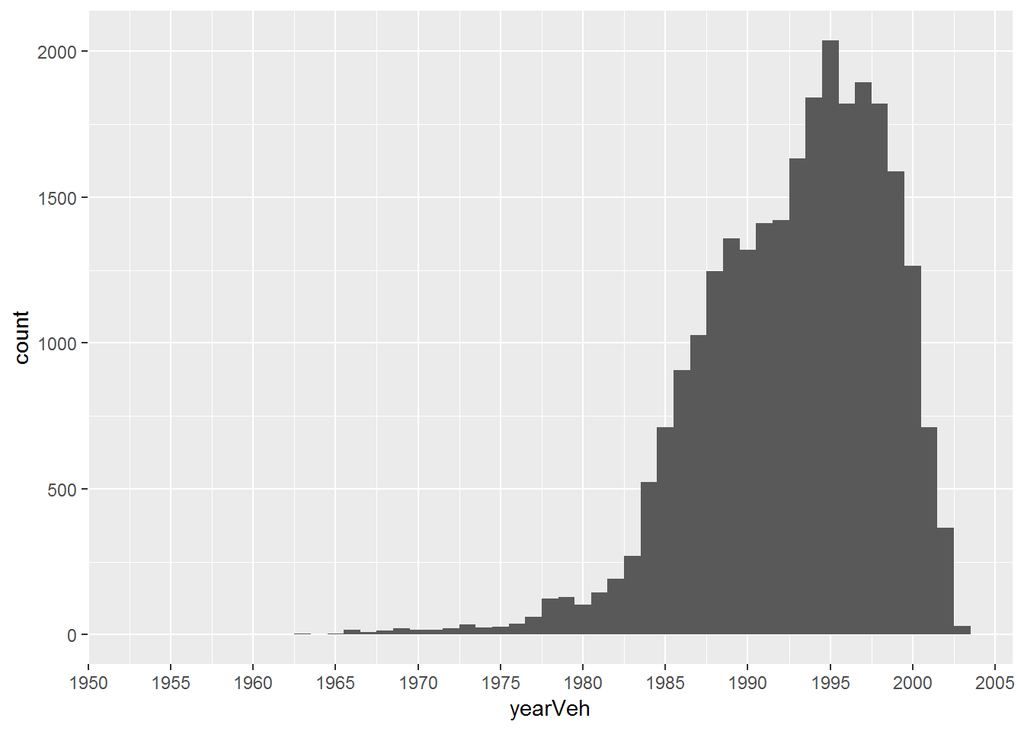

as the data is for years between 1997 and 2002 it is normal to see more models near that period not very old

## injury degree count

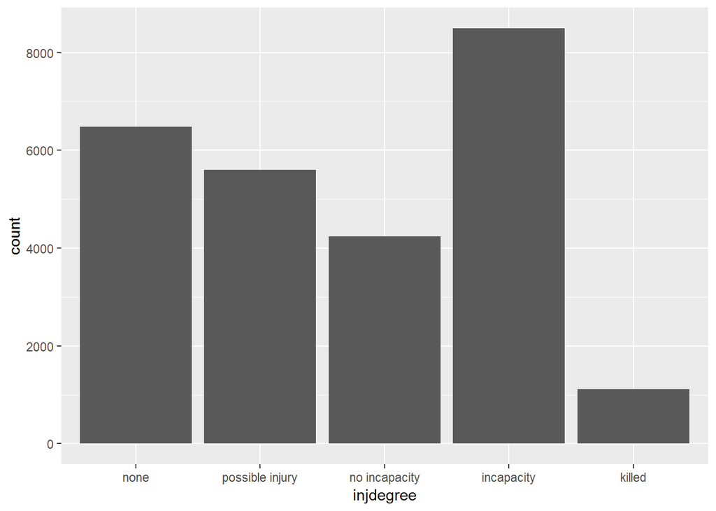

```
##            none possible injury   no incapacity      incapacity
##            6479            5595            4242            8495
##          killed         unknown     prior death            NA's
##            1118             133               2             153
```

incapacity injury is the mood after it come none injury then possible injury then no incapacity injuries and the least is killed

# Univariate Analysis

### the structure of the dataset

- the data consists of 20 variables and 26217 observations

### the distributions of some variables

- the most accidents occurred in the range 10-24 and the fasterabove it the less
- males have more accidents than females
- the older the less accidents with the peak between 16 and 24
- the data is for years between 1997 and 2002 it is normal to see more models near that period not very old
- incapacity injury is the mood after it come none injury then possible injury then no incapacity injuries and the least is killed

### to do next

looking at those factors and airbag and there effect on injuries and death

# Bivariate Plots Section

## death rate by speed

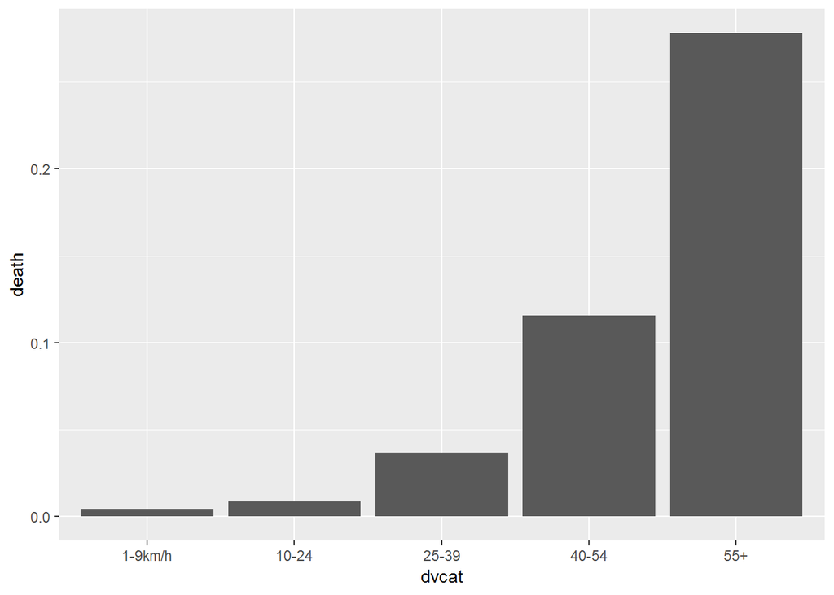

sound that the higher the speed the higher the death rate

## injury by speed

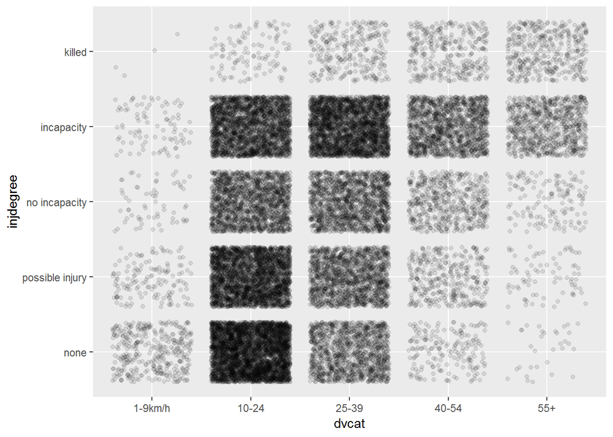

sound that the higher the speed the worse the injury

## death rate by airbag catigory

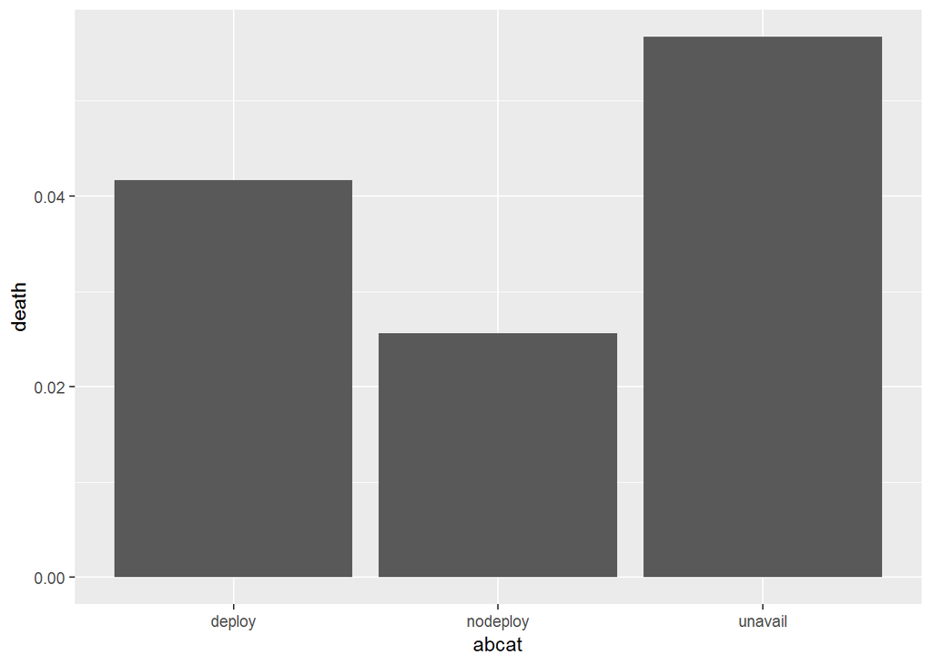

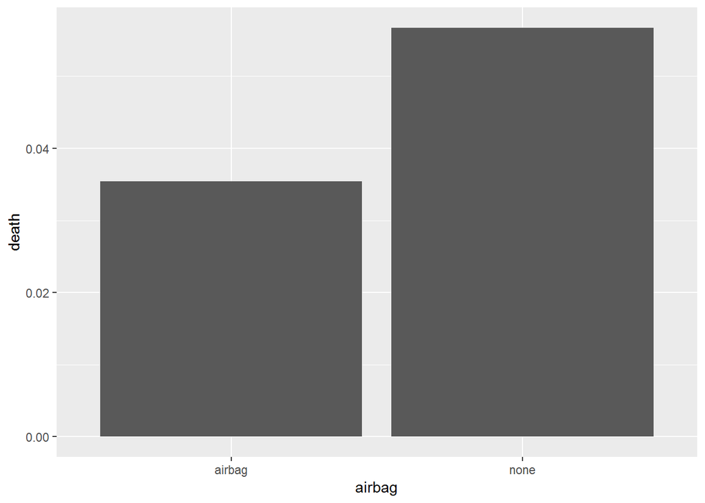

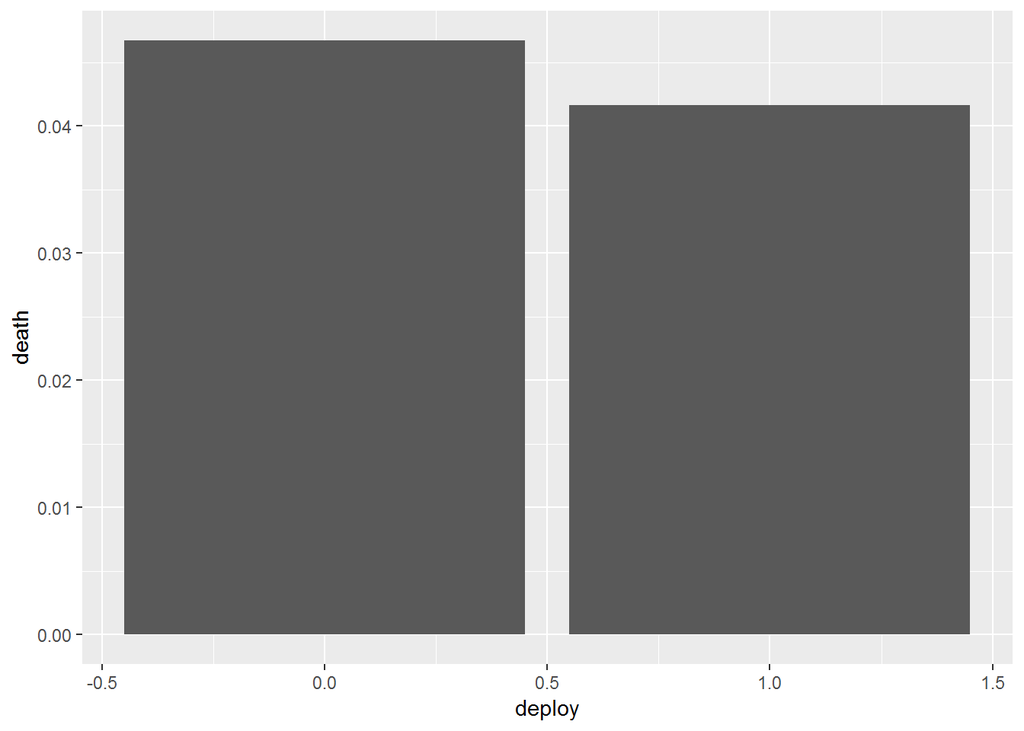

sound that airbags are doing there job as death rate is lower with airbags

## death rate by seatbelt

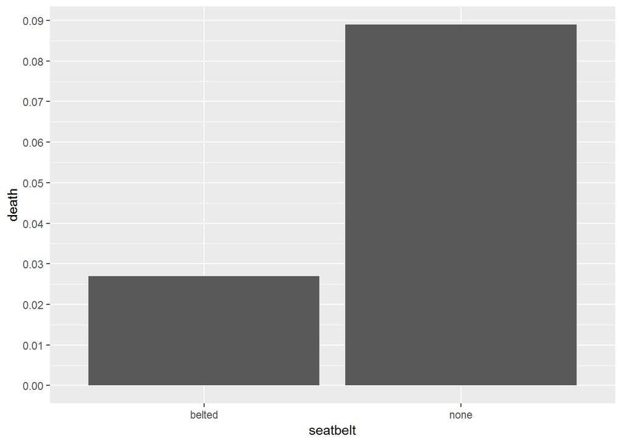

sound that seatbelts are doing there job better than airbags as death rate is lower with belted seatbelts

## gender by death rate and seatbelt using

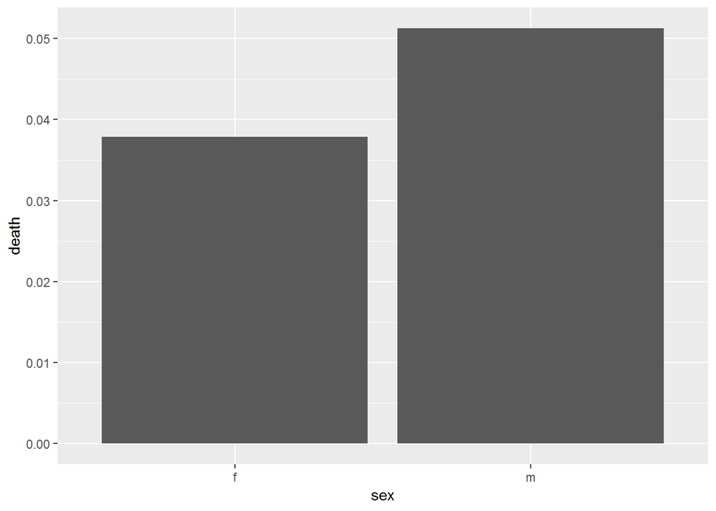

```
## df$sex: f
## [1] 0.03788374
## --------------------------------------------------------
## df$sex: m
## [1] 0.05125635
```

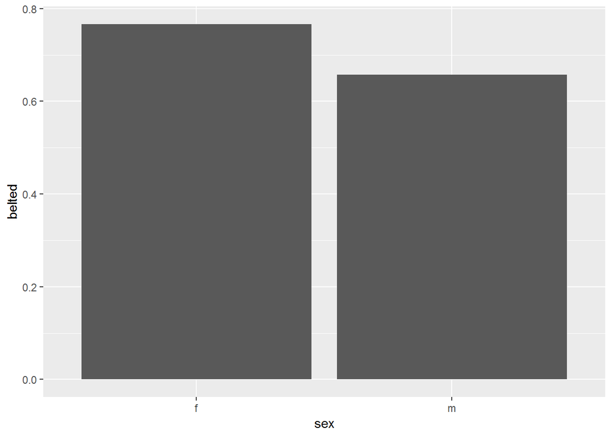

males have higher death rate and males use seatbelt less

## death rate by age

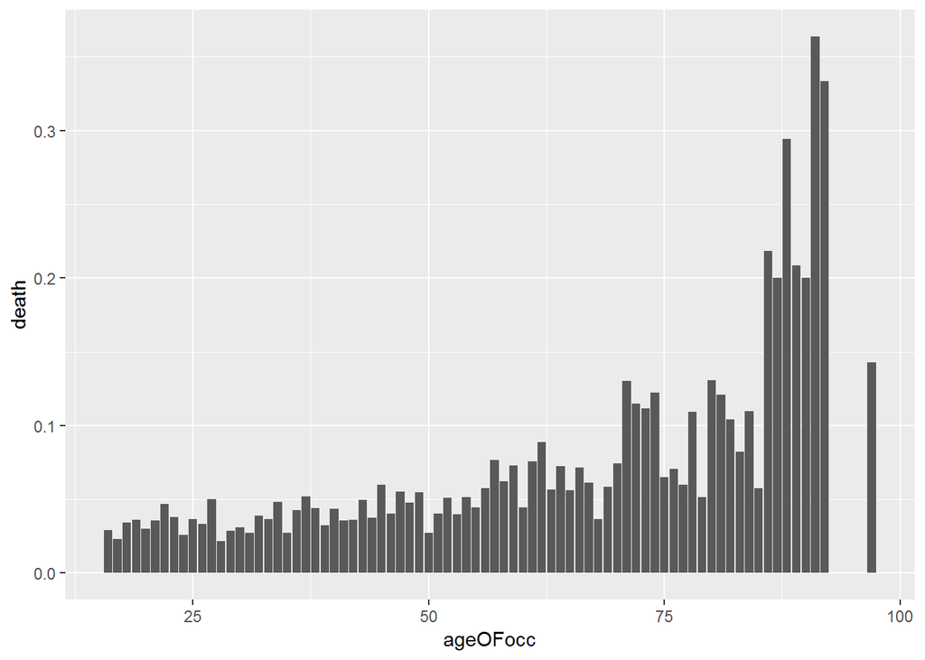

looks like the higher the age the higher death rate

## death rate by model year

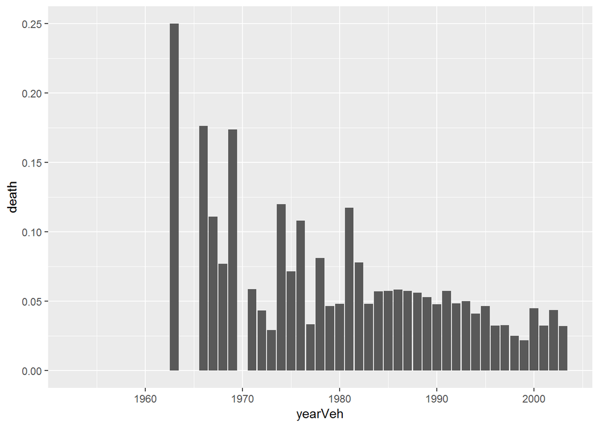

death rate for modern car are less than old ones in general

## drivers compared to passenger death rate and seatbelt using

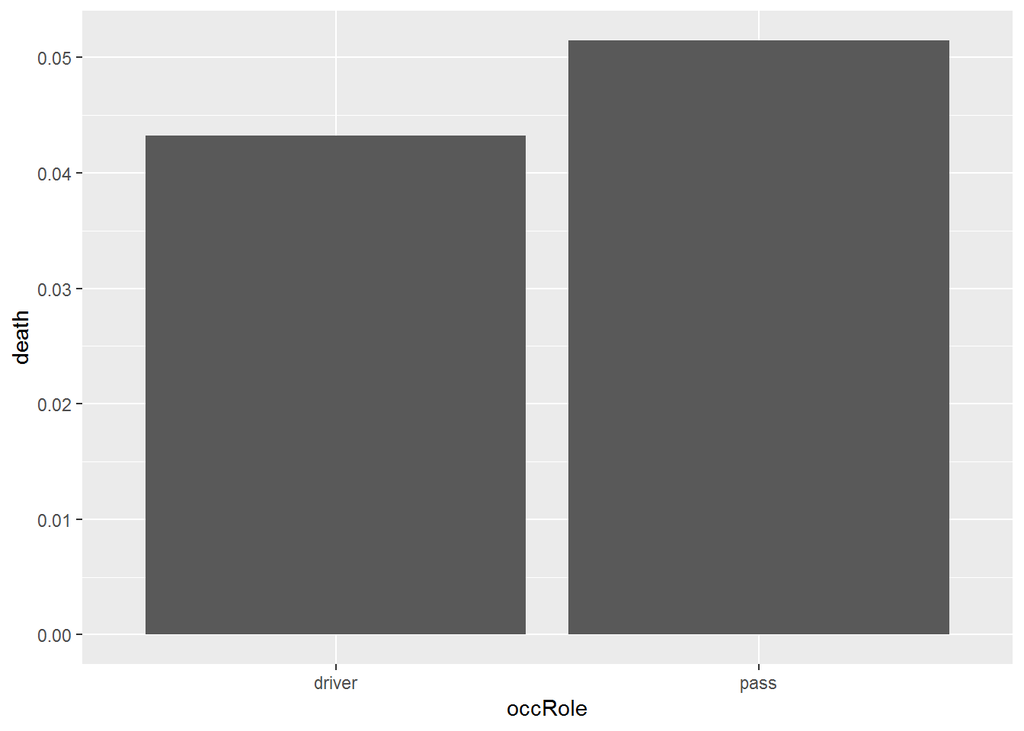

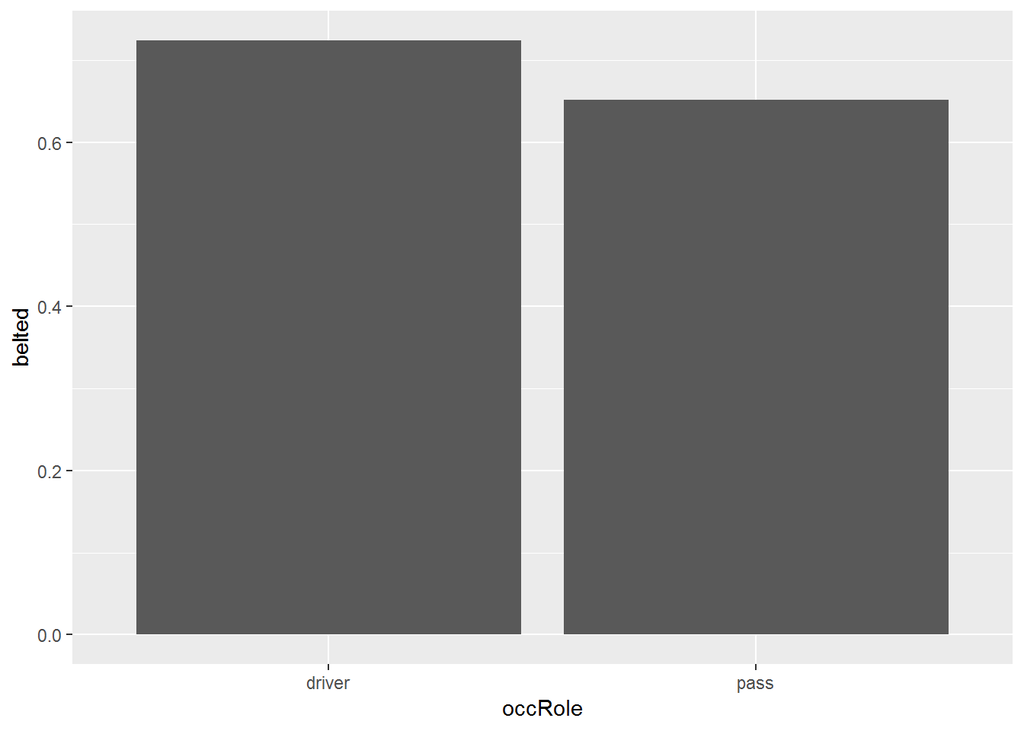

death rate for passenger is higher than drivers and they use seatbelt less too

## direction of impact by death rate

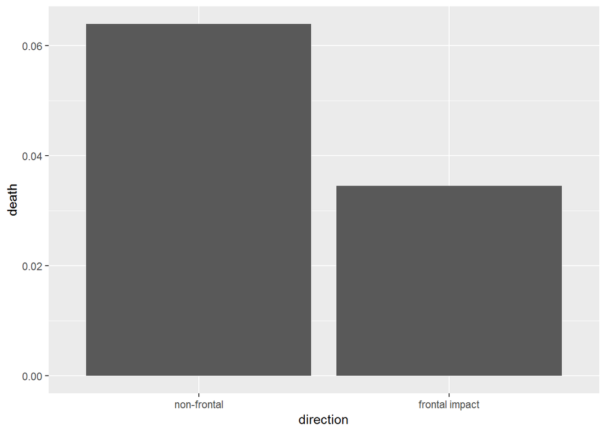

frontal impact has less death rate

## injury by airbag

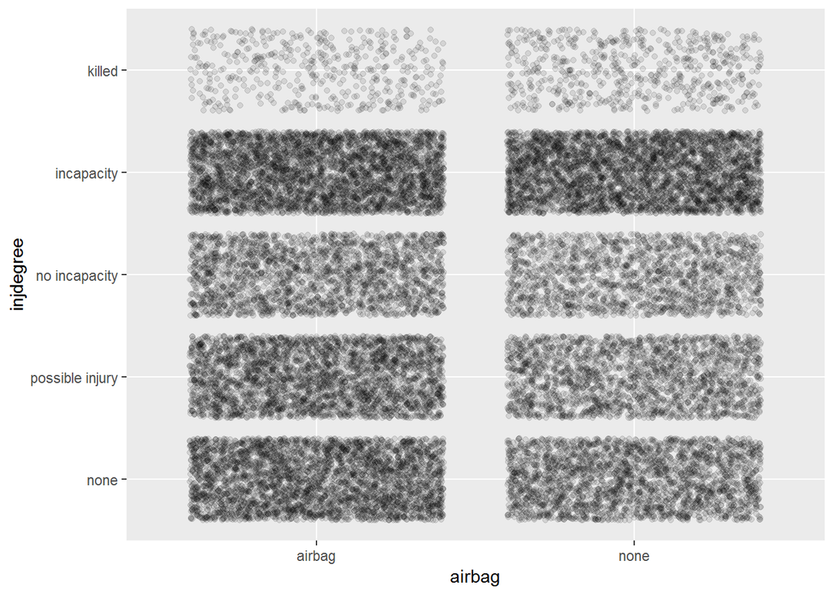

not very clear

# Bivariate Analysis

- the higher the speed the higher the death rate
- the higher the speed the worse the injury
- airbags are doing there job
- seatbelts are doing there job better than airbags
- males have higher death rate and males use seatbelt less
- the higher the age the higher death rate
- death rate for modern car are less than old ones in general
- death rate for passenger is higher than drivers and they use seatbelt less too
- frontal impact has less death rate than non-frontal ones

# Multivariate Plots Section

## death rate by airbag catigory faceted by speed

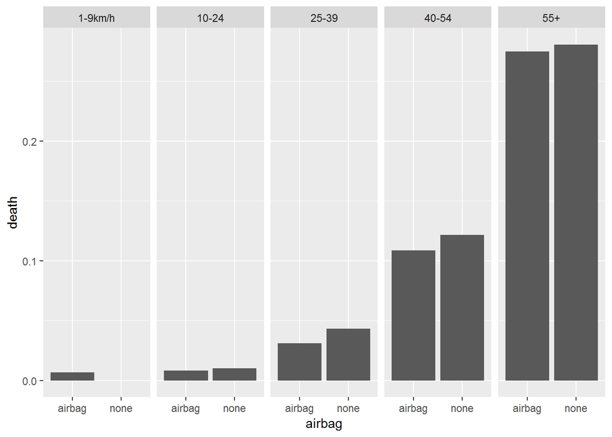

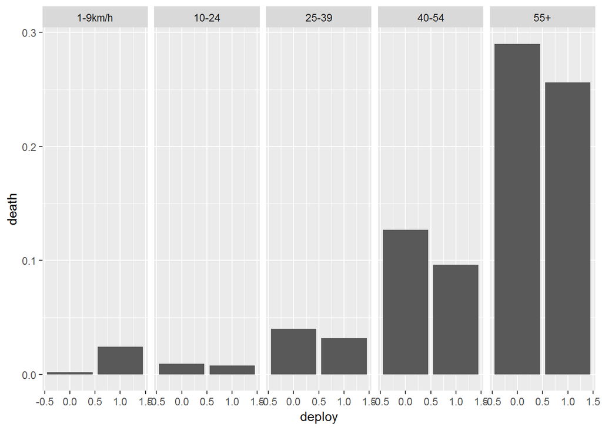

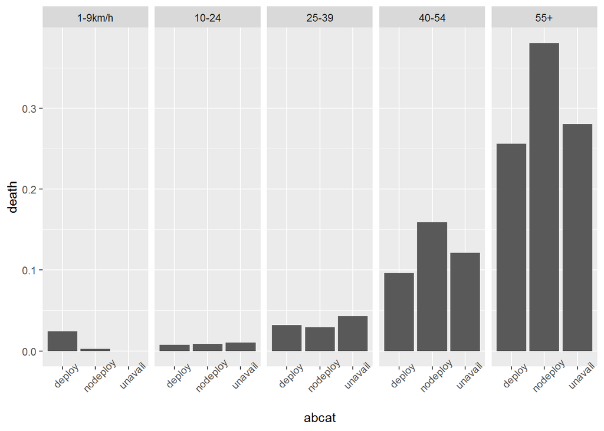

there is a problem with airbags at low spead and the death rate is higher

## airbag by count faceted by injury

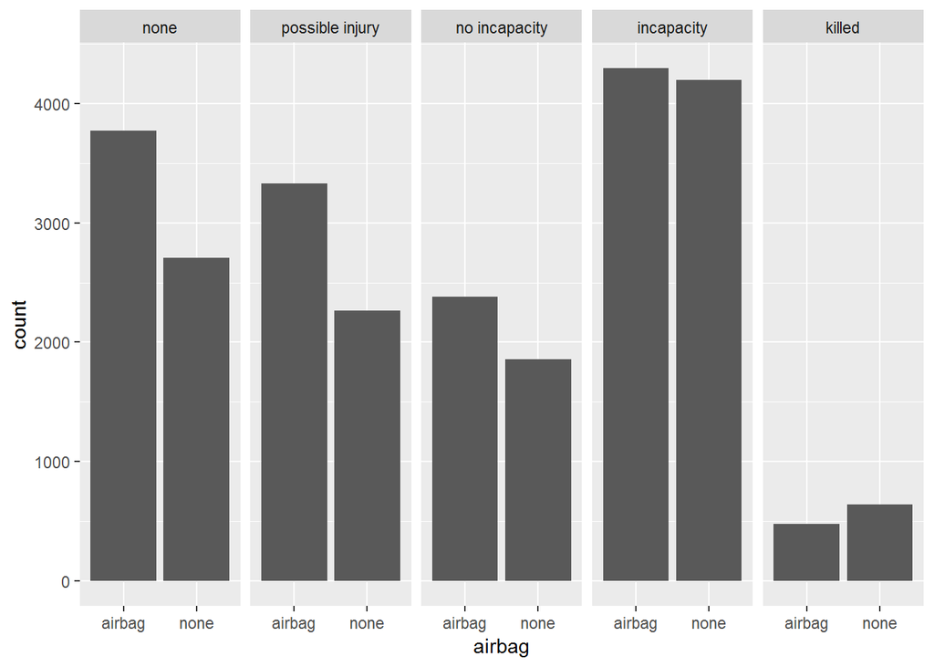

very interesting more injuries happen with airbags than without them but death is more with out them

## injury by speed faceted by airbag

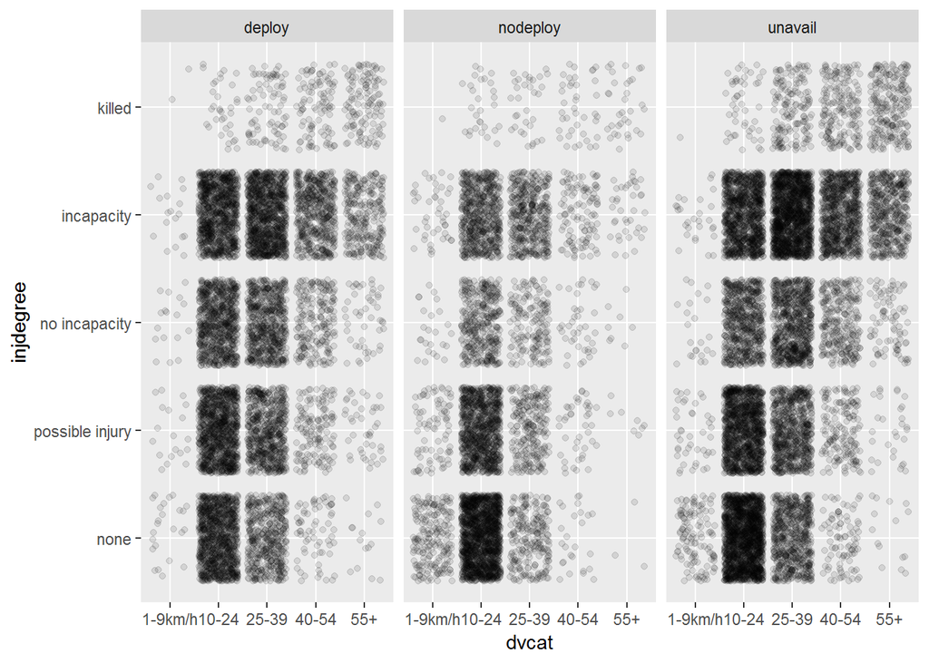

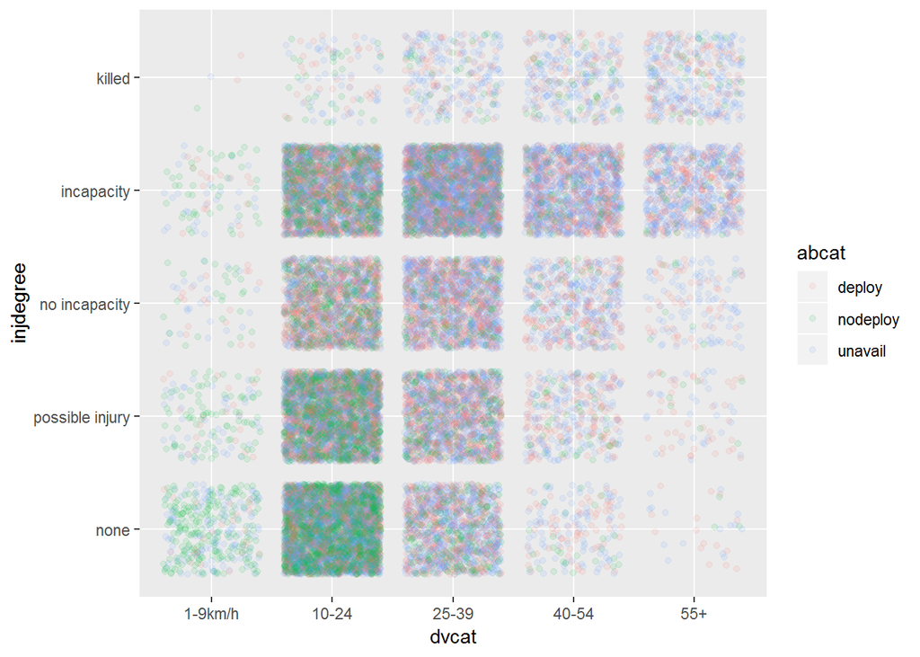

it seems that airbags are working in general

## death rate by seatbelt faceted by speed

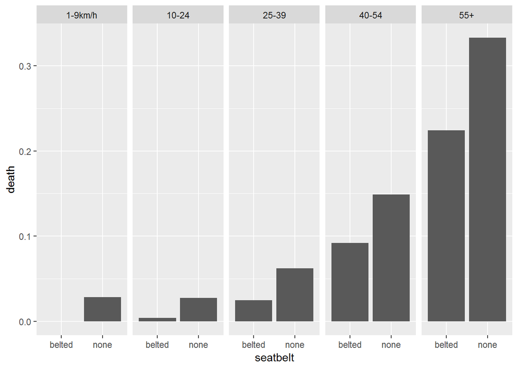

it seems that seatbelts are doing well across all speeds

# Multivariate Analysis

- there is a problem with airbags at low spead and the death rate is higher
- it seems that airbags are working in general
- it seems that seatbelts are doing well across all speeds
- the effect of seatbelt on fatality rate looks larger than airbags in general
- very interesting more injuries happen with airbags than without them but death is more with out them

# Final Plots and Summary

### Plot One

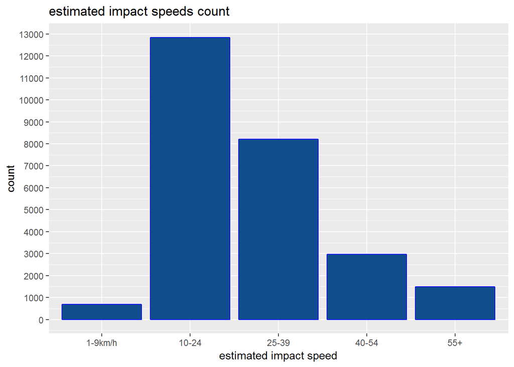

### Description One

sound strange the most accidents occurred in the range 10-24 and the faster above it the less accidents

### Plot Two

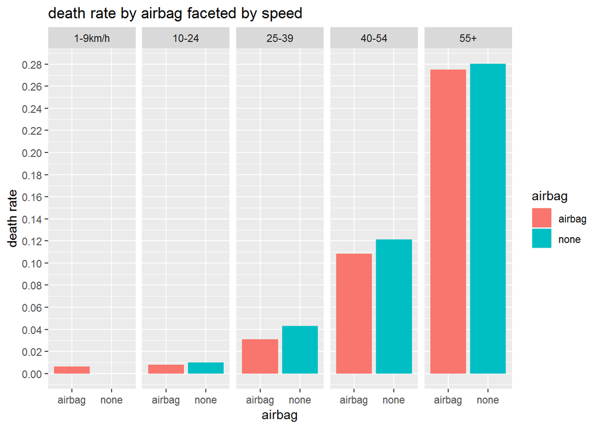

### Description Two

- it seems that death rate is lower in presence of airbags except for low speed impact which sound strange
- it is clear that although more accidents occure at low speed the death rate for high speed is higher

### Plot Three

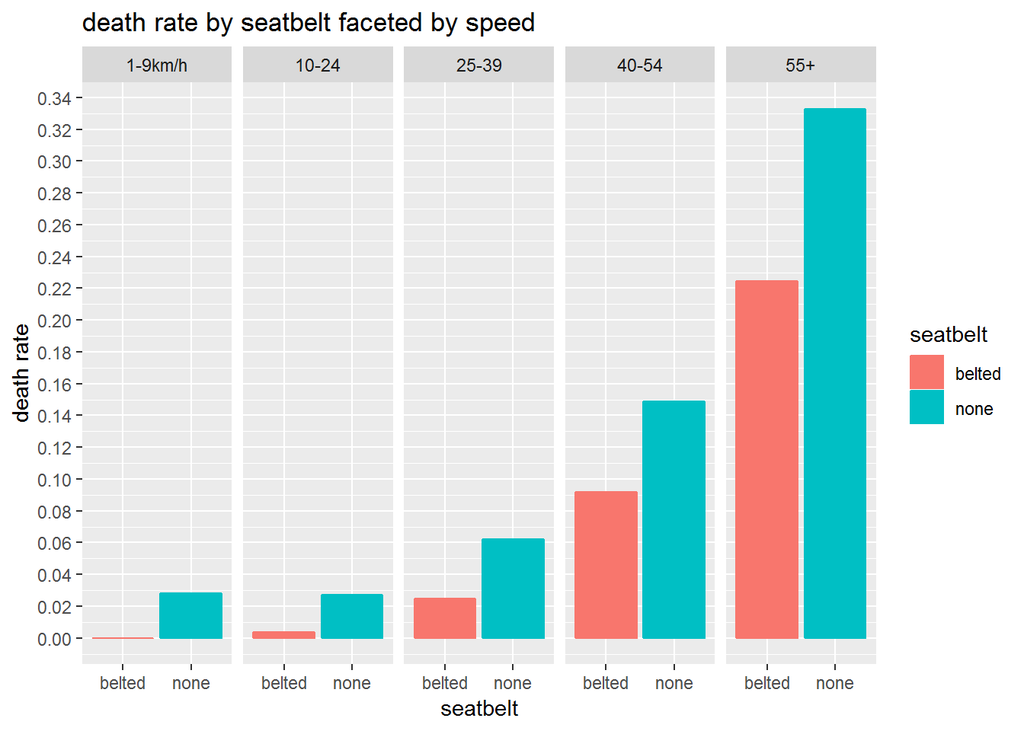

### Description Three

it seems that death rate is well lower when seatbelts are belted

# Reflection

- the data set was good easy to work with
- there is not enough quantitative variables to work with
- death rate at low speed was strange as it was higher in presence of airbag and that need more investigation
- more work could be done on injuries and its degrees may be by extracting dummy from it and see its rates related to other factors
- making dummy variables made it easy to compare rates
- the shortage in quantitative variable make it hard to make scatterblot
- because the is alot of catigorical variable the bar blot is the best to use